# Siegelman_MachineLearning_Project

Ben Siegelman

2023-12-31

## Executive Summary

This report describes the creation and execution of a predictive model on motion sensor data, designed to predict the type of movement being done. The data was pre-processed into training, testing, and validation sets and compressed using logical decisions and assessment of highly correlated variables. A random forest model was selected and run on the testing set. It was then explored for possible problems and run again on the validation set. Errors were examined and assessed. The estimated accuracy of the model on out of sample data is described in bolded text towards the bottom of the report.

## Question

The prediction process works best when guided by a specific, concrete question. In our case, the question is: What combination of variables best indicate which manner of exercise or “classe” is being performed?

## Cross Validation

The large dataset allowed for robust cross-validation. I partitioned the data into a training set containing 60% of observations, a test set with 20% of observations, and a validation set with 20% of observations. This allowed me to train models on the training set and use the testing set to explore results and make revisions if needed, before running the final model on the validation set once only.

I also used k-fold cross-validation, using 5 cross-validated folds. The large dataset allowed a smaller number of folds while still ensuring heterogeneity in each fold, which helped to avoid overfitting.

## Model Selection

I ruled out generalized linear models and regularized regression based on exploratory data analysis and because our response variable is a factor. Based on the structure of the data, LDA and Naive Bayes seemed unlikely to be optimal choices. Boosting methods are prone to overfitting, which I cannot easily mitigate without contextual background on the variable meanings. I therefore selected a Random Forest approach, as it was well suited to a factor response variable with a large number of predictors whose relationships were largely unknown due to lack of metadata.

I used parallel processing and 5-fold cross-validation to run the random forest model.

```r
## set up parallel processing
library(parallel)
library(doParallel)
cluster <- makeCluster(detectCores() - 1)
registerDoParallel(cluster)
## set the number of cross-validation folds at 5
fitControl <- trainControl(method = "cv",
                           number = 5,
                           allowParallel = TRUE)

##Random Forest model with parallel processing
rf_parallel <- train(classe~., method= "rf", data = training, trControl = fitControl)
stopCluster(cluster)
registerDoSEQ()
```

## Results

The random forest model performed quite well on the testing set:

```r
## predicting on test set
rf1_predict <- predict(rf_parallel, newdata=testing)
rf1_conf <- confusionMatrix(rf1_predict, testing$classe)
acc1 <- rf1_conf$overal["Accuracy"]
acc1_lower <- rf1_conf$overal["AccuracyUpper"]
acc1_upper <- rf1_conf$overal["AccuracyLower"]
kappa1 <- rf1_conf$overal["Kappa"]
rf1_conf$overall
```

```
##       Accuracy          Kappa  AccuracyLower  AccuracyUpper   AccuracyNull
##      0.9898141      0.9871131      0.9861553      0.9927134      0.2834225
## AccuracyPValue  McnemarPValue
##      0.0000000            NaN
```

The accuracy on the testing set was **0.9898141**, with a 95% confidence interval of **0.9927134 - 0.9861553 accuracy**. The Kappa statistic is **0.9871131**, indicating a high rate of agreement not equivalent to chance.

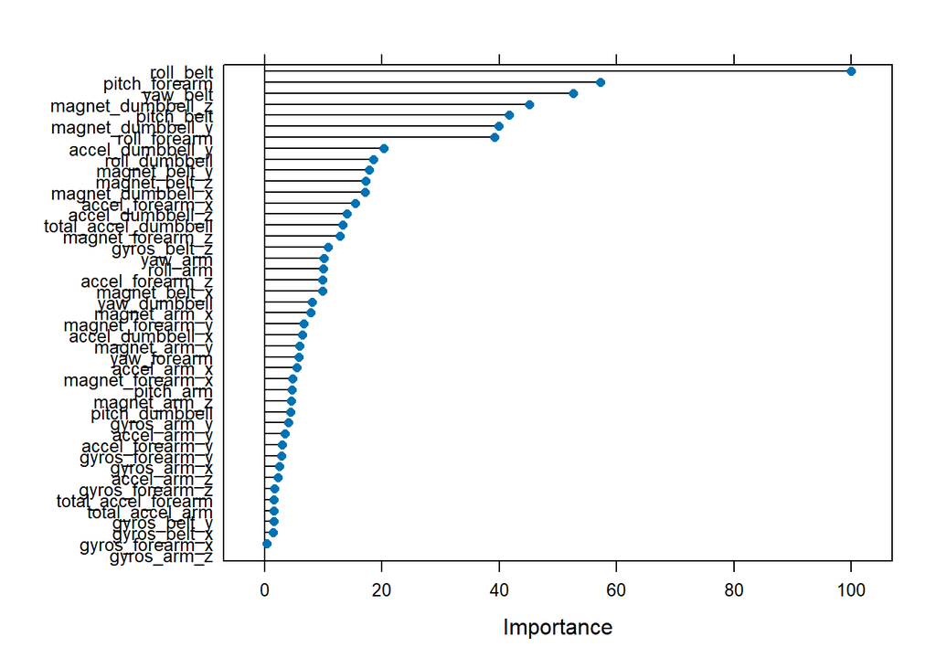

The plot shows that the top 7 variables are especially important for the model, with roll_belt being by far the most important. Because I’m ignorant of the predictor variables and worried about over-fitting and/or multi-collinearity, I checked whether any of these seven especially important variables are highly correlated.

```r
## isolate the names of the top 7 most important variables
top_vars <- rownames(varImp(rf_parallel)$importance)[1:7]
top_vars_data <- training[, top_vars]
## run a correlation matrix on those
top_corr <- cor(top_vars_data)
## define 'high correlation' as anything above .75
highcorr_top<- which(top_corr > 0.75 & top_corr < 1, arr.ind = TRUE)
## use a 'for' loop to return a text result with the variables and their correlation
for (i in 1:nrow(highcorr_top)) {
     row_index <- highcorr_top[i, 1]
     col_index <- highcorr_top[i, 2]
     correlation_value <- top_corr[row_index, col_index]

     cat("Variables:", rownames(top_corr)[row_index], "and", colnames(top_corr)[col_index],
         "have a high correlation of", correlation_value, "\n")
}
```

```
## Variables: yaw_belt and roll_belt have a high correlation of 0.816049
## Variables: roll_belt and yaw_belt have a high correlation of 0.816049
```

The variables roll_belt and yaw_belt are highly correlated. This is concerning, as these are the first and third most important variables. However, I decided to leave the model as-is for a few reasons:

1. Random forests are robust to colinearity;
2. The correlation is likely to inflate estimated importance of variables, so these two variables may be less important to the model than shown here;
3. I want to avoid the risk of over-fitting the model to this dataset by tinkering with the fine details of variables I don’t understand well due to lack of metadata; and
4. The model is performing very well on the testing set as is.

I next ran the model’s predictions on the validation set:

```r
## predicting on validation
rf_validation <- predict(rf_parallel, newdata= validation)
conf <- confusionMatrix(rf_validation, validation$classe)
acc <- conf$overal["Accuracy"]
acc_lower <- conf$overal["AccuracyUpper"]
acc_upper <- conf$overal["AccuracyLower"]
kappa <- conf$overal["Kappa"]
conf$overall
```

```
##       Accuracy          Kappa  AccuracyLower  AccuracyUpper   AccuracyNull
##      0.9900586      0.9874233      0.9864346      0.9929214      0.2844762
## AccuracyPValue  McnemarPValue
##      0.0000000            NaN
```

```r
est_acc <- 1-acc
est_acc_lower <- 1- acc_upper
est_acc_upper <- 1-acc_lower
```

The model performed similarly well on the validation set: Accuracy was **0.9900586** with a 95% confidence interval of **0.9929214 - 0.9864346**, and a Kappa statistic of **0.9874233**.

**Based on this result, the expected out of sample error is 1 - accuracy, which is 0.0099414. The 95% confidence interval for our of sample error is 0.0135654 - 0.0070786.**

Finally, I wanted to explore the errors that did occur. The following heatmap displays the proportion of mistaken predictions for each combination of ‘classe’ levels:

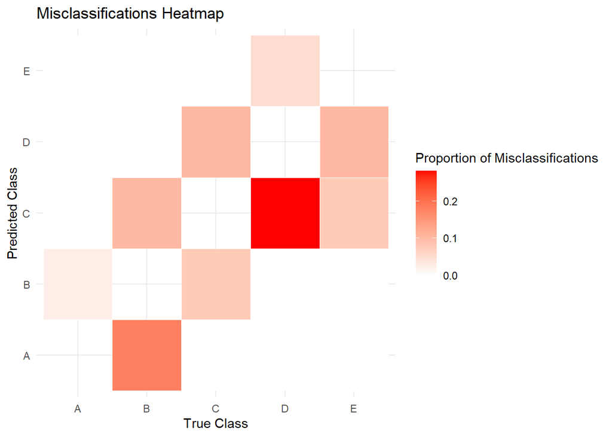

The heat map shows that the model has the most trouble mis-predicting true values of classe D as classe C. These acount for nearly one-third of errors. Mistaking classe B for classe A is the second most common, with all other error types much less common.

##Appendix

```r
data <- read.csv("~/R/Coursera/MachineLearning_Project/pml-training.csv")
test_set_quiz <- read.csv("~/R/Coursera/MachineLearning_Project/pml-testing.csv")

## pre-process data
library(dplyr)
data <- data %>%
     mutate(classe = as.factor(classe))

set.seed(1234)
library(mlbench)
## slice training set into train (60%), test (20%), and validation (20%) sets
library(caret)
train_index <- createDataPartition(y = data$classe, p = 0.8, list = FALSE)
test_index <- createDataPartition(y = train_index, p = 0.25, list = FALSE)
training <- data[train_index[-test_index], ]
testing <- data[train_index[test_index], ]
validation <- data[-c(train_index, train_index[test_index]), ]

## remove columns with at least half of cells NA or blank
training <- training %>%
     select_if(~ sum(!is.na(.) & . != "") >= 19622/2) %>%
     select(-(1:7))
## create correlation matrix with 0's at diagonal
corr <- abs(cor(training[ ,-53]))
diag(corr) <- 0
## Identify variables with high correlation
high_corr_vars <- which(corr > 0.8 & corr < 1, arr.ind = TRUE)
# Display the variables and their correlation values
for (i in 1:nrow(high_corr_vars)) {
     row_index <- high_corr_vars[i, 1]
     col_index <- high_corr_vars[i, 2]
     correlation_value <- corr[row_index, col_index]

     cat("Variables:", rownames(corr)[row_index], "and", colnames(corr)[col_index],
         "have a high correlation of", correlation_value, "\n")
}
```

```
## Variables: yaw_belt and roll_belt have a high correlation of 0.816049
## Variables: total_accel_belt and roll_belt have a high correlation of 0.980859
## Variables: accel_belt_y and roll_belt have a high correlation of 0.92445
## Variables: accel_belt_z and roll_belt have a high correlation of 0.9920139
## Variables: accel_belt_x and pitch_belt have a high correlation of 0.9662299
## Variables: magnet_belt_x and pitch_belt have a high correlation of 0.8837825
## Variables: roll_belt and yaw_belt have a high correlation of 0.816049
## Variables: roll_belt and total_accel_belt have a high correlation of 0.980859
## Variables: accel_belt_y and total_accel_belt have a high correlation of 0.9268893
## Variables: accel_belt_z and total_accel_belt have a high correlation of 0.9746788
## Variables: pitch_belt and accel_belt_x have a high correlation of 0.9662299
## Variables: magnet_belt_x and accel_belt_x have a high correlation of 0.8958577
## Variables: roll_belt and accel_belt_y have a high correlation of 0.92445
## Variables: total_accel_belt and accel_belt_y have a high correlation of 0.9268893
## Variables: accel_belt_z and accel_belt_y have a high correlation of 0.9332628
## Variables: roll_belt and accel_belt_z have a high correlation of 0.9920139
## Variables: total_accel_belt and accel_belt_z have a high correlation of 0.9746788
## Variables: accel_belt_y and accel_belt_z have a high correlation of 0.9332628
## Variables: pitch_belt and magnet_belt_x have a high correlation of 0.8837825
## Variables: accel_belt_x and magnet_belt_x have a high correlation of 0.8958577
## Variables: gyros_arm_y and gyros_arm_x have a high correlation of 0.9171714
## Variables: gyros_arm_x and gyros_arm_y have a high correlation of 0.9171714
## Variables: magnet_arm_x and accel_arm_x have a high correlation of 0.814801
## Variables: accel_arm_x and magnet_arm_x have a high correlation of 0.814801
## Variables: magnet_arm_z and magnet_arm_y have a high correlation of 0.8146276
## Variables: magnet_arm_y and magnet_arm_z have a high correlation of 0.8146276
## Variables: accel_dumbbell_x and pitch_dumbbell have a high correlation of 0.8125143
## Variables: accel_dumbbell_z and yaw_dumbbell have a high correlation of 0.8507852
## Variables: gyros_dumbbell_z and gyros_dumbbell_x have a high correlation of 0.9869601
## Variables: gyros_forearm_z and gyros_dumbbell_x have a high correlation of 0.9455562
## Variables: gyros_dumbbell_x and gyros_dumbbell_z have a high correlation of 0.9869601
## Variables: gyros_forearm_z and gyros_dumbbell_z have a high correlation of 0.9573935
## Variables: pitch_dumbbell and accel_dumbbell_x have a high correlation of 0.8125143
## Variables: yaw_dumbbell and accel_dumbbell_z have a high correlation of 0.8507852
## Variables: gyros_forearm_z and gyros_forearm_y have a high correlation of 0.8864668
## Variables: gyros_dumbbell_x and gyros_forearm_z have a high correlation of 0.9455562
## Variables: gyros_dumbbell_z and gyros_forearm_z have a high correlation of 0.9573935
## Variables: gyros_forearm_y and gyros_forearm_z have a high correlation of 0.8864668
```